# Prueba PLS

Federico Ricardo Checozzi

2023-09-13

```r
library(tidyverse)
library(data.table)
library(mdatools)
library(rhdf5)
```

Dataset de entrenamiento: un espectro por muestra con downsampling de longitudes de onda. Implementé el downsampling porque el costo de memoria del algoritmo crece con el número de variables y estaba empezando a usar memoria virtual.

```r
setwd(r"(C:\Users\tiama\OneDrive\Documentos\Maestría en minería y exploración de datos\Tesis de maestría\Código de prueba\output)")

spectra <- fread("SNV1_downsampled.csv", dec = ',',header = TRUE)
class <- fread("train_samples_class.csv", dec = ',',header = TRUE)
```

Para hacer la validación cruzada, uso el método de “persiana veneciana” como aparece en el paper de LIBS. Elegir segmentos aleatoriamente no parece cambiar demasiado el resultado. mdatools utiliza el algoritmo SIMPLS.

```r
start_time <- Sys.time()
model <- plsda(spectra,as.factor(class$trainClass),cv = list('ven', 5))
end_time <- Sys.time()

end_time - start_time
```

```
## Time difference of 6.588266 mins
```

El problema con estos modelos es que consiguen buena exactitud al costo de generar muchos falsos negativos. ¿Será por la falta de datos o porque la función eligió modelos muy simples por defecto? Notese que eligió un solo componente (¿Por qué? La documentación dice que busca el primer mínimo local en la curva de RMSE).

```r
summary(model)
```

```
##
## PLS-DA model (class plsda) summary
## ------------------------------------
## Info:
## Number of selected components: 1
## Cross-validation: venetian blinds with 5 segments
##
## Class #1 (1)
##     X cumexpvar Y cumexpvar TP FP TN FN Spec. Sens. Accuracy
## Cal       13.82        8.58  0  0 91  9     1     0     0.91
## Cv           NA          NA  0  0 91  9     1     0     0.91
##
## Class #2 (2)
##     X cumexpvar Y cumexpvar TP FP TN FN Spec. Sens. Accuracy
## Cal       13.82        8.58  0  0 85 15     1     0     0.85
## Cv           NA          NA  0  0 85 15     1     0     0.85
##
## Class #3 (3)
##     X cumexpvar Y cumexpvar TP FP TN FN Spec. Sens. Accuracy
## Cal       13.82        8.58  0  0 95  5     1     0     0.95
## Cv           NA          NA  0  0 95  5     1     0     0.95
##
## Class #4 (4)
##     X cumexpvar Y cumexpvar TP FP TN FN Spec. Sens. Accuracy
## Cal       13.82        8.58  0  0 94  6     1     0     0.94
## Cv           NA          NA  0  0 94  6     1     0     0.94
##
## Class #5 (5)
##     X cumexpvar Y cumexpvar TP FP TN FN Spec. Sens. Accuracy
## Cal       13.82        8.58  0  0 93  7     1     0     0.93
## Cv           NA          NA  0  0 93  7     1     0     0.93
##
## Class #6 (6)
##     X cumexpvar Y cumexpvar TP FP TN FN Spec. Sens. Accuracy
## Cal       13.82        8.58  0  0 91  9     1     0     0.91
## Cv           NA          NA  0  0 91  9     1     0     0.91
##
## Class #7 (7)
##     X cumexpvar Y cumexpvar TP FP TN FN Spec. Sens. Accuracy
## Cal       13.82        8.58  0  0 95  5     1     0     0.95
```

[output cut: 11 more lines]

```
##
## Class #10 (10)
##     X cumexpvar Y cumexpvar TP FP TN FN Spec. Sens. Accuracy
## Cal       13.82        8.58  0  0 95  5     1     0     0.95
## Cv           NA          NA  0  0 95  5     1     0     0.95
##
## Class #11 (11)
##     X cumexpvar Y cumexpvar TP FP TN FN Spec. Sens. Accuracy
## Cal       13.82        8.58  0  0 88 12     1     0     0.88
## Cv           NA          NA  0  0 88 12     1     0     0.88
##
## Class #12 (12)
##     X cumexpvar Y cumexpvar TP FP TN FN Spec. Sens. Accuracy
## Cal       13.82        8.58  0  0 94  6     1     0     0.94
## Cv           NA          NA  0  0 94  6     1     0     0.94
```

Gráfico de error en función del número de componentes:

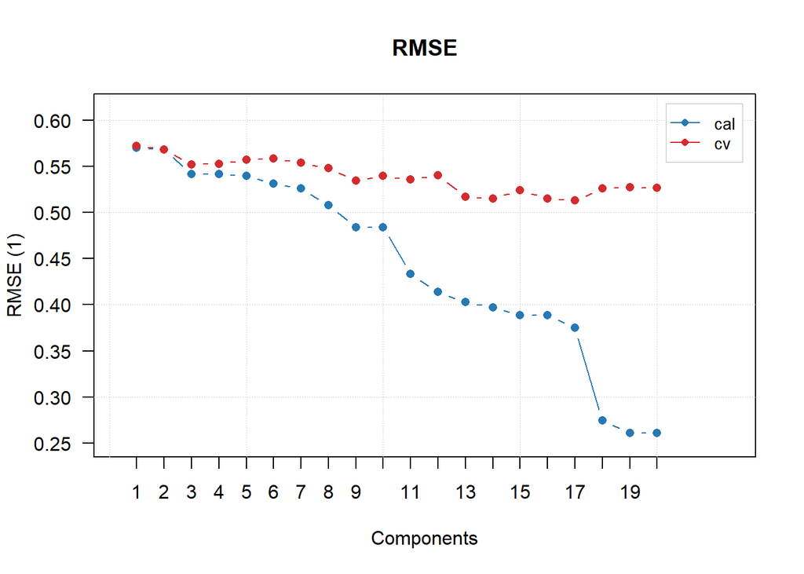

```r
plotRMSE(model)
```

Gráfico Q vs. T2 (lo vi en el paper EMSLIBS2019, como parte de la validación cruzada o una predicción genera las estadísticas correspondientes):

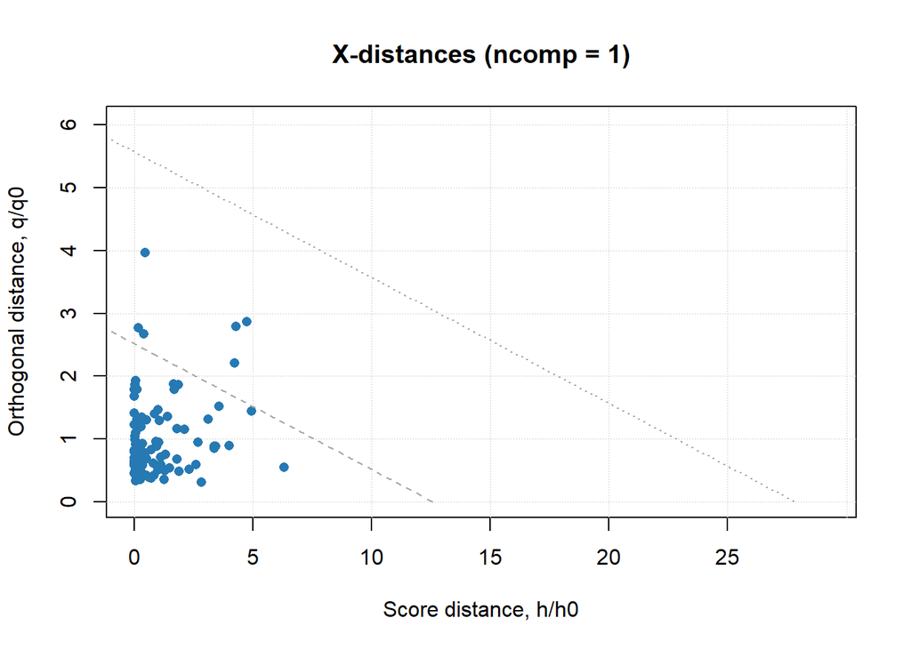

```r
plotXResiduals(model)
```

Predicción en el dataset de prueba:

```r
setwd("C:/Users/tiama/OneDrive/Documentos/Dataset EMSLIBS2019/")
##########################################
# Test Data
##########################################
start_time <- Sys.time()
testData <- h5read(file = "test_downsampled.h5", name = "UNKNOWN") # import spectra
h5closeAll()

test_class <- fread("test_labels.csv", dec = ',',header = FALSE)

##########################################
# Merge
##########################################


testData <- as.data.frame(do.call('rbind',testData))

##########################################
# End of loading script
##########################################

test_res = predict(model, testData, as.factor(test_class$V1))

end_time <- Sys.time()

end_time - start_time
```

```
## Time difference of 3.950882 mins
```

Los resultados son bastante malos:

```r
summary(test_res)
```

```
##
## PLS-DA results (class plsdares) summary:
## Number of selected components: 1
##
## Class #1 (1):
##         X expvar X cumexpvar Y expvar Y cumexpvar TP  FP    TN   FN Spec. Sens.
## Comp 1    17.474      17.474   39.942      39.942  0   0 16854 3146 1.000 0.000
## Comp 2     9.218      26.692    1.253      41.195  0   0 16854 3146 1.000 0.000
## Comp 3     7.332      34.024    4.227      45.422  0   0 16854 3146 1.000 0.000
## Comp 4     7.552      41.576    3.319      48.741  0   0 16854 3146 1.000 0.000
## Comp 5     9.687      51.263    0.449      49.190  0   0 16854 3146 1.000 0.000
## Comp 6     7.788      59.051   -0.875      48.315  0   0 16854 3146 1.000 0.000
## Comp 7     4.403      63.454   -0.301      48.014  0   0 16854 3146 1.000 0.000
## Comp 8     2.996      66.450    2.038      50.052  0   1 16853 3146 1.000 0.000
## Comp 9     2.251      68.702    0.341      50.393  0   5 16849 3146 1.000 0.000
## Comp 10    1.258      69.959   -0.003      50.390  0   6 16848 3146 1.000 0.000
## Comp 11    1.479      71.439   -1.362      49.029  7   4 16850 3139 1.000 0.002
## Comp 12    0.292      71.730    1.312      50.341 49  12 16842 3097 0.999 0.016
## Comp 13    0.603      72.334    0.489      50.830 28  20 16834 3118 0.999 0.009
## Comp 14    0.927      73.261   -2.025      48.804 28  22 16832 3118 0.999 0.009
## Comp 15    0.151      73.412    0.091      48.896 40  20 16834 3106 0.999 0.013
## Comp 16    0.245      73.657    1.166      50.061 40  23 16831 3106 0.999 0.013
## Comp 17    0.684      74.341    0.382      50.444 70  58 16796 3076 0.997 0.022
## Comp 18    0.193      74.534   -1.468      48.976 55 202 16652 3091 0.988 0.017
## Comp 19    0.317      74.851   -0.137      48.839 59 330 16524 3087 0.980 0.019
## Comp 20    0.254      75.106   -0.600      48.239 56 349 16505 3090 0.979 0.018
##         Accuracy
## Comp 1     0.843
## Comp 2     0.843
## Comp 3     0.843
## Comp 4     0.843
## Comp 5     0.843
## Comp 6     0.843
## Comp 7     0.843
## Comp 8     0.843
## Comp 9     0.842
## Comp 10    0.842
## Comp 11    0.843
## Comp 12    0.845
## Comp 13    0.843
```

[output cut: 487 more lines]

```
## Comp 6         1
## Comp 7         1
## Comp 8         1
## Comp 9         1
## Comp 10        1
## Comp 11        1
## Comp 12        1
## Comp 13        1
## Comp 14        1
## Comp 15        1
## Comp 16        1
## Comp 17        1
## Comp 18        1
## Comp 19        1
## Comp 20        1
```

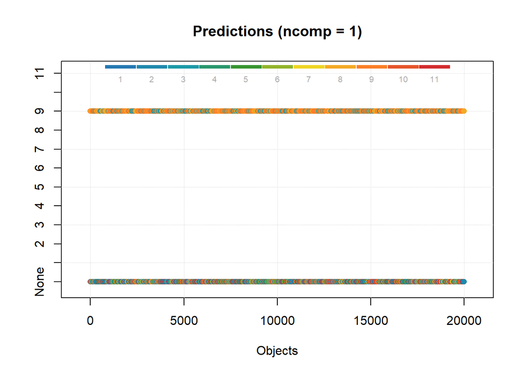

```r
plotPredictions(test_res)
```

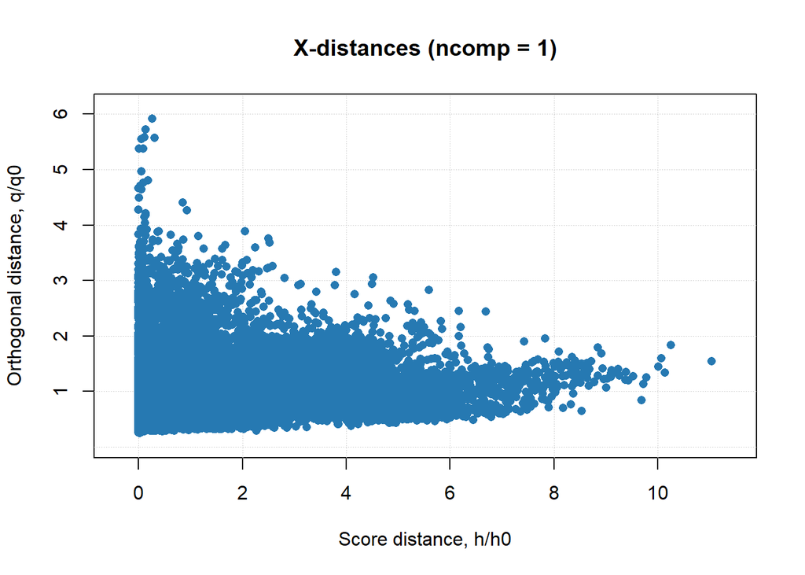

```r
plotXResiduals(test_res)
```

```r
getConfusionMatrix(test_res)
```

```
##    1 2 3 4 5 6 7 8   9 10 11 12 None
## 1  0 0 0 0 0 0 0 0   0  0  0  0 3146
## 2  0 0 0 0 0 0 0 0   0  0  0  0 3129
## 3  0 0 0 0 0 0 0 0 420  0  0  0  123
## 4  0 0 0 0 0 0 0 0   3  0  0  0 1600
## 5  0 0 0 0 0 0 0 0   0  0  0  0 1048
## 6  0 0 0 0 0 0 0 0   0  0  0  0 1589
## 7  0 0 0 0 0 0 0 0   0  0  0  0  560
## 8  0 0 0 0 0 0 0 0 316  0  0  0 1230
## 9  0 0 0 0 0 0 0 0 914  0  0  0 2213
## 10 0 0 0 0 0 0 0 0   1  0  0  0  513
## 11 0 0 0 0 0 0 0 0   1  0  0  0 3194
```

Aún no encuentro una manera de que el programa me genere un vector de predicciones directamente (raro y algo frustrante), pero tengo esta matriz que almacena -1 y 1 para PLS de cada clase, así que en el peor caso podría armar una función:

```r
test_res$c.pred
```

[output not shown]

[output cut: 14993 more lines]

La documentación de mdatools puede verse en estos links, hay un montón de métodos implementados: https://mdatools.com/docs/plsda.html https://cran.r-project.org/web/packages/mdatools/mdatools.pdf